# Introdução à Ciência de Dados

Mestrado Profissional em Administração

Prof. Washington Santos da Silva

IFMG - Campus Formiga

15 de maio de 2025

## Diário de Bordo

**O que vimos até aqui?**

- Aula 1 ✅
  - Apresentação da Disciplina ✅
  - Introdução e Contextualização ✅
  - O que é Ciência de Dados? ✅
  - Pesquisa Reproduzível e Ciência de Dados ✅
  - Papéis Profissionais ✅
  - Aplicações ✅
  - Habilidades Interpessoais e Analíticas ✅
  - Apresentação da Disciplina ✅
  - Configurações: Git/GitHub ✅
- Aula 2 ✅
  - Metodologia CRISP-DM ✅
  - Tipos de Análise de Dados ✅
  - Introdução ao RStudio e criação do **seu** Projeto da Disciplina ✅
  - Introdução ao Sistema de Publicação Quarto ✅
  - Introdução ao Git e GitHub: controle de versão e criação do **seu** repositório no GitHub ✅
- Aula 3 ✅
  - Breve Revisão sobre o RStudio ✅
  - Sistema de Publicação Quarto: (Cont.) ✅
  - Introdução ao Git e GitHub: (Cont.) ✅
  - Sessão Prática: Fluxo de trabalho integrando RStudio/Quarto/R/Git/GitHub ✅
- Aula 4 ✅
  - Conceitos de Variáveis e Observações em Estatística ✅
  - Conceito de Dados Organizados (*Tidy Data*) ✅
  - Tipos atômicos e classes principais de dados da linguagem R ✅
  - Tipos de Dados Tradicionais em Finanças: ✅
    - Dados em Secção-Cruzada (ou Transversal) (*Cross-Section Data*) ✅
    - Dados em Secções-Cruzadas Combinadas (*Pooled Cross-Section Data*) ✅
    - Dados em Séries Temporais (*Time Series Data*) ✅
    - Dados em Painel (ou Longitudinais) (*Panel Data*) ✅
  - Importação e Preparação de Dados Típicos de Finanças com exemplos práticos ✅
- Aula 5 ✅
  - Metodologia CRISP-DM: Fases 2 e 3 ✅
  - Revisão sobre Dados Organizados (*Tidy Data*) ✅
  - Introdução ao Pacote tidyr: função pivot_longer() ✅
  - Introdução ao Pacote dplyr: funções select() e filter() ✅

## Na última Aula

**Tópicos Vistos**

- Metodologia CRISP-DM: Fases 2 e 3 ✅
- Revisão sobre Dados Organizados (*Tidy Data*) ✅
- Introdução ao Pacote tidyr: função pivot_longer() ✅
- Introdução ao Pacote dplyr: funções select() e filter() ✅

## Nesta Aula

**Tópicos Planejados**

- Introdução ao Pacote dplyr
  - Função mutate
  - Funções group_by e summarize

**Diretrizes para Aulas Mais Produtivas**

⌨️ **Código com método:**

95% dos erros são evitáveis com:

- Atenção na digitação
- Respeitar a sequência lógica de etapas
- Revisão antes de pedir ajuda

🤝 **Inteligência colaborativa:**

- Compartilhe conhecimento
- Resolva questões técnicas simples com colegas próximos
- Reserve ao professor as dúvidas conceituais complexas

💪 **Capacidade de Resolver Problemas**

Cada erro resolvido é uma evolução da sua habilidade analítica

# Função dplyr::mutate()

## O que é a função mutate()?

**Criando e transformando variáveis**

- A função `mutate()` permite **criar novas variáveis** ou **modificar variáveis existentes**
- Enquanto `filter()` seleciona linhas e `select()` seleciona colunas, `mutate()` **adiciona ou modifica colunas**
- É como ter uma “calculadora” que cria novas informações a partir dos dados existentes
- Ideal para cálculos como: percentuais, totais, médias, categorias, etc.

## Função mutate()

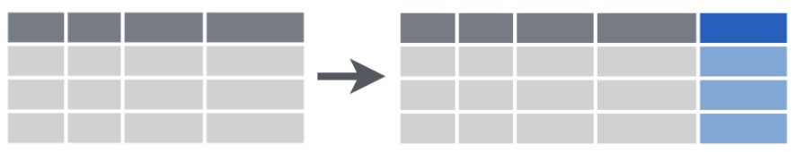

Cria novas variáveis a partir das variáveis existentes

## Sintaxe da função mutate()

**Como usar mutate() na prática**

```r
# Formato básico
dados %>% mutate(nova_coluna = expressão)

# Exemplos práticos
dados %>% mutate(valor_total = preco * quantidade)
dados %>% mutate(valor_com_desconto = preco * 0.9)
```

**O que cada parte significa:**

- **nova_coluna**: Nome da nova variável que você está criando
- **expressão**: Fórmula que calcula os valores da nova variável
- A expressão é aplicada a cada linha individualmente

## Aplicação: Análise de Vendas

**Cenário: Relatório de análise comercial**

Imagine que a data frame `gapminder` contém dados de vendas globais da sua empresa:

```r
# Criando variáveis para análise de vendas
vendas_analise <- gapminder %>%
  filter(year == 2007) %>%  # Filtra dados somente de 2007
  mutate(
    # PIB total representa a receita total da região
    receita_total = gdpPercap * pop,
    # Receita em milhões (para facilitar a leitura)
    receita_milhoes = receita_total / 1000000,
    # Indicador de destaque (regiões com alta receita por pessoa)
    destaque = gdpPercap > 20000
  ) %>%
  # Vamos visualizar apenas algumas colunas e 5 linhas
  select(country, receita_milhoes, gdpPercap, destaque) %>%
  head(5)

vendas_analise
```

[output not shown]

**Interpretação administrativa:** Este tipo de transformação é usado diariamente nas empresas para converter dados brutos em métricas de negócios úteis para tomada de decisão.

## Mutações Simples

**Transformações mais comuns: Operações aritméticas básicas**

```r
# Operações aritméticas básicas com mutate()
gapminder %>%
  filter(country == "Brazil", year >= 2000) %>%
  mutate(
    # Adição: adiciona um valor fixo
    pop_ajustada = pop + 1000000,
    # Multiplicação: multiplica por um fator
    gdp_reais = gdpPercap * 5.2,  # Convertendo para reais
    # Divisão: divide para mudar a escala
    pop_milhoes = pop / 1000000   # População em milhões
  ) %>%
  select(year, pop, pop_ajustada, pop_milhoes, gdpPercap, gdp_reais)
```

[output not shown]

**Dica:** As operações mais utilizadas em análises de negócios são multiplicação (para fatores, taxas, conversões) e divisão (para mudar escalas e calcular proporções).

## Criando categorias com ifelse()

**O que é a função ifelse()?**

A função `ifelse()` permite criar novas variáveis categóricas baseadas em condições:

**Como funciona:** `ifelse(condição, valor_se_verdadeiro, valor_se_falso)`

```r
# Criando categorias com ifelse
paises_categorizados <- gapminder %>%
  filter(year == 2007) %>%
  mutate(
    nivel_desenvolvimento = ifelse(gdpPercap > 10000,
                                   "Desenvolvimento Alto",
                                   "Desenvolvimento Baixo")
  ) %>%
  select(country, gdpPercap, nivel_desenvolvimento) %>%
  head(6)

paises_categorizados
```

[output not shown]

- É como dizer: “SE o PIB per capita for maior que 10.000, então classifique como ‘Desenvolvimento Alto’, SENÃO classifique como ‘Desenvolvimento Baixo’”

## Criando KPIs com ifelse()

**Criando KPIs com mutate() e ifelse()**

```r
gapminder %>%
 filter(year == 2007) %>%
 mutate(
   pib_total = gdpPercap * pop,  # PIB total
   pib_percentual_global = (pib_total/sum(pib_total))*100, # % do PIB global
   performance = ifelse(gdpPercap > mean(gdpPercap),
                       "Acima da média",
                       "Abaixo da média")
 ) %>%
 select(country, pib_total, pib_percentual_global, performance)
```

[output not shown]

Isso mostra como transformar dados brutos em informações gerenciais.

## Múltiplas Categorias com case_when()

**Quando precisamos de mais de duas categorias**

`case_when()` é como um “sistema de classificação” para criar categorias mais complexas:

```r
# Exemplo de múltiplas categorias
paises_classificados <- gapminder %>%
  filter(year == 2007) %>%
  mutate(
    classe_desenvolvimento = case_when(
      gdpPercap < 2000 ~ "Baixo",
      gdpPercap < 10000 ~ "Médio",
      gdpPercap >= 10000 ~ "Alto"
    )
  ) %>%
  select(country, gdpPercap, classe_desenvolvimento) %>%
  head(6)

paises_classificados
```

[output not shown]

**Como funciona:**

- Cada linha representa uma condição: `condição ~ "valor a atribuir"`
- As condições são verificadas em ordem (de cima para baixo)
- Quando uma condição é verdadeira, o valor correspondente é atribuído

## Quando usar ifelse() vs. case_when()?

**Escolhendo a função adequada**

| Função | Quando usar | Exemplo |
| --- | --- | --- |
| `ifelse()` | Para divisões simples em duas categorias | `ifelse(vendas > meta, "Meta atingida", "Meta não atingida")` |
| `case_when()` | Para múltiplas categorias ou condições complexas | Classificar clientes em “Bronze”, “Prata”, “Ouro” e “Platina” baseado em diferentes critérios |

**Analogia de negócios:**

- `ifelse()` é como uma decisão “sim/não” (aprovação de crédito simples)
- `case_when()` é como um sistema de classificação de clientes com várias categorias

## Erros Comuns e Como Evitá-los

**Os erros que todos cometem no início**

1. **Usar o operador de atribuição errado**
   - ERRADO: `mutate(nova_var <- expressão)` ❌
   - CORRETO: `mutate(nova_var = expressão)` ✅
2. **Esquecer de salvar o resultado**
   - ERRADO: `dados %>% mutate(nova_var = x * 2)` ❌ (resultado não salvo)
   - CORRETO: `dados_novos <- dados %>% mutate(nova_var = x * 2)` ✅
3. **Tentar usar variáveis que acabou de criar sem manter os resultados**

ERRADO:

```r
# Executando dois comandos separados:
dados %>% mutate(nova_var = x * 2)  # Resultado não salvo em lugar nenhum
dados %>% filter(nova_var > 10)     # ❌ Erro! nova_var não existe em 'dados'
```

CORRETO (Pipeline único):

```r
dados_novos <- dados %>%
  mutate(nova_var = x * 2) %>%
  filter(nova_var > 10) # ✅ Funciona porque tudo está no mesmo pipeline
```

## Resumo: Função mutate()

**O que você precisa lembrar**

1. **O que faz:** `mutate()` cria novas variáveis ou modifica existentes
2. **Usos comuns no mundo dos negócios:**
   - Calcular totais, médias, porcentagens
   - Converter unidades (dólares para reais, unidades para milhares)
   - Criar categorias e classificações
3. **Como usar na prática:**

```r
dados %>% mutate(nova_variavel = expressão)
```

4. **Ferramentas complementares:**
   - `ifelse()` para classificações simples (sim/não)
   - `case_when()` para classificações múltiplas
5. **Lembre-se de salvar o resultado em um novo objeto:**

```r
novo_df <- dados %>% mutate(...)
```

## Sua vez

**Exercícios Práticos**

**Nível 1: Começando com mutate()**

1. Complete o código abaixo para criar uma nova variável que converta a população para milhões:

```r
gapminder %>%
  mutate(pop_em_milhoes = ___)
```

2. Crie uma nova variável que calcule a “receita total” (PIB per capita × população) para cada país.

**Nível 2: Aplicando categorias**

3. Usando `ifelse()`, crie uma variável chamada `economia_grande` que seja “Sim” quando a população for maior que 50 milhões e “Não” caso contrário.
4. **Desafio**: Usando dados de 2007, crie uma variável que classifique os países em três categorias baseadas na expectativa de vida:
   - “Baixa”: menos de 60 anos
   - “Média”: entre 60 e 75 anos
   - “Alta”: mais de 75 anos

**Dica:** Não se preocupe se não conseguir resolver todos. Foque em entender a lógica!

# Funções dplyr::group_by() e dplyr::summarize()

## O que são as funções group_by() e summarize()?

**Agrupando e resumindo dados**

- A função `group_by()` permite **agrupar dados** por uma ou mais variáveis categóricas
- A função `summarize()` (ou `summarise()`) permite **calcular estatísticas resumidas** para cada grupo
- Estas funções geralmente trabalham juntas como uma ferramenta poderosa para análise
- É como criar “subtotais” ou “relatórios consolidados” por categorias (ex: vendas por região, despesas por departamento)

## Funções group_by() e summarize()

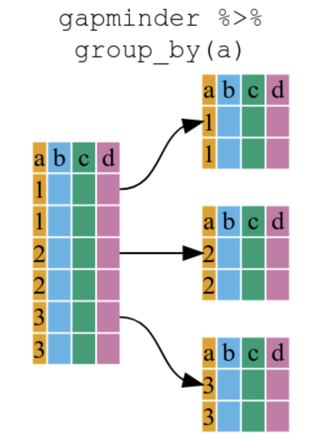

## Sintaxe das funções group_by() e summarize()

**Sintaxe básica**

```r
# Estrutura básica
df %>%
  group_by(variavel_de_agrupamento) %>%
  summarize(nome_do_resumo = funcao(variavel))

# Exemplo prático
df %>%
  group_by(departamento) %>%
  summarize(media_vendas = mean(vendas))
```

- **df**: A data frame que contém os dados
- **variavel_de_agrupamento**: Variável **categórica** pela qual agrupar (ex: região, produto)
- **nome_do_resumo**: Nome que você escolhe para o resultado calculado
- **funcao**: Função estatística (ex: mean, sum, max, min, sd, n)
- **variavel**: Variável para calcular a estatística

## Exemplo: Análise Financeira por Continente

**Cenário: Relatório para executivos sobre desempenho regional**

Imagine que você é um analista financeiro e precisa preparar um relatório executivo comparando regiões:

```r
# Cria um relatório de PIB médio por continente
relatorio_continentes <- gapminder %>%
  filter(year == 2007) %>%  # Filtra para dados mais recentes
  group_by(continent) %>%   # Agrupa por continente
  summarize(
    PIB_medio = mean(gdpPercap),         # Média do PIB per capita
    Total_populacao = sum(pop),          # População total
    Paises_analisados = n(),             # Número de países
    PIB_minimo = min(gdpPercap),         # PIB mínimo
    PIB_maximo = max(gdpPercap)          # PIB máximo
  ) %>%
  arrange(desc(PIB_medio))  # Ordena do maior para o menor PIB médio

# Visualiza o resultado
relatorio_continentes
```

[output not shown]

**Interpretação** Este tipo de relatório consolidado por região é crítico para análises comparativas entre mercados e para apresentações executivas. Mostra claramente as estatísticas-chave para cada grupo (continente), facilitando comparações e decisões estratégicas.

## Funções Estatísticas Mais Usadas com summarize()

**Funções Estatísticas da linguagem R**

| Função | O que calcula | Exemplo em R | Uso em Negócios |
| --- | --- | --- | --- |
| `mean()` | Média | `mean(vendas)` | Valor médio de vendas por região |
| `sum()` | Soma total | `sum(receita)` | Receita total por categoria |
| `min()` | Valor mínimo | `min(preco)` | Menor preço praticado |
| `max()` | Valor máximo | `max(despesa)` | Maior despesa do período |
| `sd()` | Desvio padrão | `sd(producao)` | Variabilidade da produção |
| `n()` | Contagem de linhas | `n()` | Número de transações |
| `n_distinct()` | Contagem de valores únicos | `n_distinct(cliente)` | Número de clientes únicos |
| `median()` | Mediana | `median(vendas)` | Valor típico de vendas |

**Dica para gestores:** Sempre inclua tanto medidas de “tendência central” (média, mediana) quanto de “variação” (desvio padrão) para ter uma visão mais completa dos dados.

## Agrupando por Múltiplas Variáveis

**Análises mais detalhadas**

```r
# Análise de expectativa de vida por continente e ano
tendencias_por_continente <- gapminder %>%
  group_by(continent, year) %>%  # Agrupa por DUAS variáveis
  summarize(
    expectativa_vida_media = mean(lifeExp),
    paises_analisados = n()
  ) %>%
  arrange(continent, year)

# Mostra resultados parciais
tendencias_por_continente %>%
  filter(continent == "Americas") %>%
  head(3)
```

```
# A tibble: 3 × 4
# Groups:   continent [1]
  continent  year expectativa_vida_media paises_analisados
  <fct>     <int>                  <dbl>             <int>
1 Americas   1952                   53.3                25
2 Americas   1957                   56.0                25
3 Americas   1962                   58.4                25
```

**Contexto empresarial:** Este tipo de análise é comum em:

- Relatórios de vendas por região e trimestre
- Análise de desempenho por departamento e mês
- Monitoramento de métricas por produto e canal de vendas

## Erros Comuns e Como Evitá-los

**Os erros que todos cometem no início**

| Erro | Errado | Correto |
| --- | --- | --- |
| Não usar summarize após group_by | `dados %>% group_by(regiao)` | `dados %>% group_by(regiao) %>% summarize(...)` |
| Tentar agrupar antes de filtrar | `group_by(regiao) %>% filter(mean(vendas) > 1000)` | Usar `filter()` ANTES de `group_by()` |
| Esquecer de desagrupar | Continuar usando dados agrupados | Usar `ungroup()` quando terminar com análises agrupadas |

**Dica:** `group_by` por si não produz nenhum resultado.

## Resumo: Funções group_by() e summarize()

**O que você precisa lembrar**

1. **Para que servem:**
   - `group_by()`: Agrupa dados por categorias (como agrupar linhas em uma planilha)
   - `summarize()`: Calcula estatísticas para cada grupo (como criar subtotais)
2. **Sintaxe básica:**

```r
dados %>%
  group_by(categoria) %>%
  summarize(resumo = funcao(variavel))
```

3. **Funções estatísticas básicas:**
   - Para totais: `sum()`
   - Para médias: `mean()`
   - Para contagens: `n()`
   - Para mínimos/máximos: `min()`, `max()`
4. **Fluxo de trabalho típico:**
   - Primeiro filtre os dados (`filter()`)
   - Depois agrupe (`group_by()`)
   - Em seguida calcule estatísticas (`summarize()`)
   - Por fim, ordene os resultados (`arrange()`)
5. **Lembre-se sempre de salvar o resultado:**

```r
relatorio_final <- dados %>% group_by(...) %>% summarize(...)
```

## Sua Vez

**Exercícios Práticos**

**Nível 1: Primeiros Passos**

1. Complete o código abaixo para calcular a média de expectativa de vida por continente:

```r
expectativa_por_continente <- gapminder %>%
  group_by(___) %>%
  summarize(expectativa_media = ___(___))
```

2. Calcule a população total por continente no ano de 2007.

**Nível 2: Análise de Negócios**

3. Imagine que cada país representa uma filial da sua empresa. Crie um relatório que mostre, para cada continente:
   - O número de “filiais” (países)
   - O PIB per capita médio (indicador de desempenho)
   - O PIB per capita da melhor “filial” (máximo)
4. **Desafio:** Crie um relatório que mostre a evolução da expectativa de vida média do continente americano ao longo dos anos (dica: agrupe por ano, filtre para mostrar apenas as Américas).

**Dica:** Lembre-se de salvar seus resultados em objetos com nomes descritivos e de usar `arrange()` para organizar seus resultados de forma lógica.

# Função dplyr::arrange()

## Função arrange()

**Ordena resultados**

- A função `arrange()` ordena as linhas (observações) de uma data frame com base nos valores de uma ou mais colunas (variáveis)
- Por padrão, organiza em ordem **crescente** (do menor para o maior)
- Use `desc()` para ordenar em ordem decrescente (do maior para o menor)

## Função arrange()

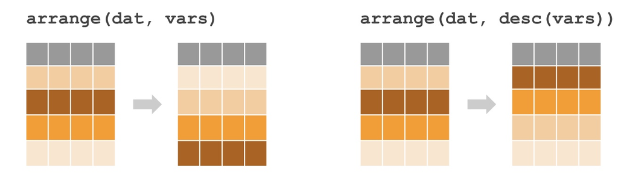

Reordena as linhas de uma data frame segundo uma variável, por padrão em ordem crescente, com desc() em ordem decrescente

## Sintaxe da função arrange()

**Como usar arrange() na prática**

```r
# Formato básico
df %>% arrange(variavel)         # ordem crescente
df %>% arrange(desc(variavel))   # ordem decrescente

# Ordenar por múltiplas variáveis
dados %>% arrange(var1, var2)       # Ordenar primeiro por var1, depois var2
```

- **df**: A data frame que contém os dados
- **variavel**: Nome da coluna pela qual você quer ordenar as observações
- Use `desc()` para ordem descrescente (do maior para o menor)
- Quando ordenando por múltiplas variáveis, a primeira tem prioridade

## Aplicação: Análise de Desempenho

**Cenário: Relatório de análise de mercado**

Imagine que você é um analista de mercado e precisa identificar rapidamente os países mais promissores para expansão:

```r
# Criando um ranking de países por PIB per capita em 2007
ranking_paises <- gapminder %>%
  filter(year == 2007) %>%                # Filtra dados apenas de 2007
  select(country, continent, gdpPercap) %>% # Seleciona colunas relevantes
  arrange(desc(gdpPercap)) %>%            # Ordena do maior para o menor PIB
  head(6)                                # Mostra os 10 primeiros resultados

# Visualiza o resultado
ranking_paises
```

```
# A tibble: 6 × 3
  country          continent gdpPercap
  <fct>            <fct>         <dbl>
1 Norway           Europe       49357.
2 Kuwait           Asia         47307.
3 Singapore        Asia         47143.
4 United States    Americas     42952.
5 Ireland          Europe       40676.
6 Hong Kong, China Asia         39725.
```

**Interpretação** Este tipo de ordenação é relevante em análises de mercado para identificar rapidamente os países mais ricos (potenciais mercados premium) ou para encontrar as regiões que precisam de mais atenção (ordenando do menor para o maior).

## Erros Comuns e Como Evitá-los

**Cuidados ao usar arrange()**

| Erro | Problema | Solução |
| --- | --- | --- |
| Ordem incorreta | `arrange(dados, desc())` sem especificar a variável | `arrange(dados, desc(variavel))` |
| Tentar ordenar por variável não existente | `arrange(vendas_por_regiao)` quando a coluna não existe | Verificar primeiro os nomes das colunas com `names()` |
| Não salvar o resultado ordenado | Ordenar mas não atribuir a um objeto | `dados_ordenados <- dados %>% arrange(...)` |

**Lembre-se:** A ordenação é temporária se você não salvar o resultado em um novo objeto!

## Resumo: Função arrange()

**O que você precisa lembrar**

1. **Para que serve:** Ordenar as linhas (observações) com base nos valores de uma ou mais colunas
2. **Sintaxe básica:**

```r
dados %>% arrange(variavel)         # ordem crescente
dados %>% arrange(desc(variavel))   # ordem decrescente
```

3. **Usos comuns em negócios:**
   - Criar rankings de vendedores, produtos ou regiões
   - Identificar os maiores clientes (Top 10)
   - Encontrar problemas (itens com menor desempenho)
   - Preparar dados para relatórios e apresentações
4. **Lembre-se sempre:**
   - Use `desc()` para ordem decrescente
   - Para ordenar por múltiplas colunas: `arrange(var1, var2)`
   - Salve o resultado em um novo objeto!

```r
dados_ordenados <- dados %>% arrange(...)
```

## Sua Vez

**Exercícios Práticos**

**Nível 1: Primeiros Passos**

1. Complete o código abaixo para ordenar os países por expectativa de vida (do maior para o menor):

```r
paises_ordenados <- gapminder %>%
  filter(year == 2007) %>%
  arrange(___(___))
```

2. Escreva um código para listar os 5 países com menor PIB per capita em 2007.

**Nível 2: Aplicação em Negócios**

3. Imagine que você trabalha no departamento internacional de uma empresa. Crie uma lista dos países das Américas ordenados por população (do maior para o menor) em 2007.
4. **Desafio:** Crie um ranking dos continentes baseado na expectativa de vida média de seus países em 2007. Use group_by(), summarize() e arrange().

**Dica:** Lembre-se de usar head() para limitar o número de resultados quando necessário!

## Resumo das Funções dplyr

**Resumo das seis funções principais**

| Função | Propósito |
| --- | --- |
| `dplyr::filter()` | Seleciona linhas baseadas em condições |
| `dplyr::select()` | Seleciona colunas específicas |
| `dplyr::mutate()` | Cria ou modifica colunas |
| `dplyr::group_by()` | Agrupa dados por categorias |
| `dplyr::summarize()` | Calcula estatísticas resumidas |
| `dplyr::arrange()` | Ordena linhas |

**Lembre-se**: O poder do dplyr está em combinar estas funções com o operador pipe `%>%`

## Pacote dplyr: Bibliografia Recomendada

- [R para Ciência de Dados - Cap. 3](http://pt.r4ds.hadley.nz/data-transform.html)
- [Introdução à Linguagem R - Cap. 5](https://pedropark99.github.io/Introducao_R/Cap%C3%ADtulos/04-transformacao.html)
- [Resumo](https://rstudio.github.io/cheatsheets/translations/portuguese/data-transformation_pt_br.pdf)

# Dados Organizados: Potencializando Análises de Dados

## Dados Longos = Dados Organizados

**Vantagens**

Com os dados organizados (formato longo), podemos facilmente, por exemplo:

- Calcular indicadores de desempenho por categoria e período
- Calcular indicadores de desempenho por produto e período
- Analisar tendências mensais para decisões de estoque e marketing
- etc.

## Aplicações

**Dados organizados permitem:**

- **Finanças e Controladoria**: Análise de tendências financeiras entre períodos, detecção de anomalias em despesas, comparação de desempenho entre unidades de negócio
- **Marketing**: Avaliação de ROI por canal e campanha, análise de comportamento do consumidor, segmentação de clientes baseada em múltiplas variáveis
- **Operações e Cadeia de Suprimentos**: Otimização de estoques baseada em tendências sazonais, previsão de demanda, monitoramento da cadeia de suprimentos
- **Recursos Humanos**: Análise de desempenho ao longo do tempo, identificação de fatores de turnover, planejamento de capacitação
- **Estratégia de Negócios**: Consolidação de KPIs de diversas áreas para tomada de decisão, identificação de correlações entre variáveis de negócio
- **Na prática**: Administradores frequentemente recebem dados em formatos inadequados para análise (relatórios estáticos, planilhas “bonitas”). A capacidade de reorganizar esses dados rapidamente para análise representa uma vantagem competitiva significativa.

## Um Pipeline Completo com dplyr

**Nota**

```r
# inicia com a df (gapminder) e salva o resultado final
relatorio_expectativa <- gapminder %>%
  # Filtra apenas os dados de 2007
  filter(year == 2007) %>%
  # Agrupa por continente
  group_by(continent) %>%
  # Calcula estatísticas por continente
  summarize(
    expectativa_media = mean(lifeExp),
    expectativa_minima = min(lifeExp),
    expectativa_maxima = max(lifeExp),
  ) %>%
  # Ordena do maior para o menor
  arrange(desc(expectativa_media))

# Visualiza o resultado final
relatorio_expectativa
```

```
# A tibble: 5 × 4
  continent expectativa_media expectativa_minima expectativa_maxima
  <fct>                 <dbl>              <dbl>              <dbl>
1 Oceania                80.7               80.2               81.2
2 Europe                 77.6               71.8               81.8
3 Americas               73.6               60.9               80.7
4 Asia                   70.7               43.8               82.6
5 Africa                 54.8               39.6               76.4
```

## Tabelas Profissionais

**Limitações das Data Frames Brutas em Relatórios Profissionais**

- As data frames produzidas pelos pipelines do dplyr são excelentes para **análise**, mas não são adequadas para **apresentação** em relatórios profissionais.
- A linguagem R oferece várias soluções para esta limitação:
  - O pacote **kableExtra** (que veremos a seguir) para relatórios HTML e PDF
  - O pacote **gt** para tabelas altamente personalizáveis
- Estes pacotes permitem transformar dados analíticos em tabelas com qualidade profissional, incluindo:
  - título, nomes das colunas e notas formatadas
  - destaque visual para informações importantes
  - personalização de cores, bordas e estilos de texto
  - entre outras.

## O Pacote kableExtra

**Transformando tabelas básicas em apresentações profissionais**

- O pacote `kableExtra` estende as funcionalidades da função básica `kable` do R, permitindo a criação de tabelas com qualidade de publicação.
- Foi desenvolvido para trabalhar com tabelas em documentos HTML e PDF (LaTeX).
- Permite formatar tabelas para relatórios profissionais, artigos acadêmicos e apresentações.
- É extremamente útil na Fase 6 do CRISP-DM (Implantação), quando precisamos comunicar resultados de forma clara e atrativa.

## Sintaxe Básica do kableExtra

**Fluxo básico com kableExtra**

```r
#  inicie com uma data frame
tabela_formatada <- dados %>%
  # Transforme a data frame em tabela básica
  kable(
    caption = "Título da Tabela",
    col.names = c("Nome1", "Nome2"), # Renomear colunas
    digits = 2,                      # Casas decimais
    format.args = list(decimal.mark = ",", big.mark = ".") # Define vírgula como separador decimal e ponto como separador de milhares
  ) %>%
  # Adicionar estilos
  kable_styling(
    bootstrap_options = c("striped", "hover"),
    full_width = FALSE,
    position = "center"
  )
```

- **kable()**: Converte a data frame em tabela básica
- **kable_styling()**: Aplica estilos visuais à tabela
- Outros elementos podem ser adicionados em sequência com o pipe (`%>%`)

## Integrando kableExtra com dplyr

**Pipeline para relatórios profissionais**

Em projetos de análise de dados completos, o fluxo geralmente é:

1. **Preparar dados** com `tidyr` e `dplyr`
2. **Analisar dados** com `dplyr` (filter, select, group_by, etc.)
3. **Visualizar resultados** com `ggplot2` (gráficos) e `kableExtra` (tabelas)

Um pipeline completo pode é similar com:

```r
# Pipeline completo de análise até apresentação
dados_brutos %>%
  # Fase de limpeza e preparação
  filter(...) %>%
  select(...) %>%
  mutate(...) %>%

  # Fase de análise e agregação
  group_by(...) %>%
  summarize(...) %>%

  # Fase de apresentação em tabela
  kable(...) %>%
  kable_styling(...) %>%
  column_spec(...)
```

Este fluxo integrado representa as fases 3, 4 e 6 do CRISP-DM.

## Resumo

**Pacote kableExtra**

1. **Para que serve**: Transformar tabelas de dados simples em tabelas profissionais para relatórios, apresentações e publicações.
2. **Sintaxe básica**:

```r
dados %>%
  kable(...) %>%
  kable_styling(...) %>%
  ... outras personalizações ...
```

3. **Funções principais**:
   - `kable()`: Converte data frame em tabela base
   - `kable_styling()`: Aplica estilos gerais à tabela
   - `column_spec()` e `row_spec()`: Personalizações específicas
   - `footnote()`: Adiciona notas de rodapé
4. **Integrações estratégicas**:
   - Ideal no final de pipelines dplyr para apresentar resultados
   - Complementar aos gráficos do ggplot2 em relatórios
5. **Benefícios em Administração**:
   - Eleva a qualidade visual de relatórios gerenciais
   - Facilita a comunicação de insights de dados para gestores
   - Permite destacar KPIs e métricas críticas para tomada de decisão

## Tabela com o Pacote KableExtra

Tabela 1: Expectativa de Vida (em anos) por Continente (2007)

```r
# inicia com a df contendo o resultado do pipeline
relatorio_expectativa %>%
  # Converte a df em uma tabela kable (tabela básica HTML/LaTeX)
  kable(
    # Renomeia as colunas para português
    col.names = c(
      "Continente", "Expectativa Média", "Expectativa Mínima", "Expectativa Máxima"
    ),
    # Formata os números com 1 casa decimal
    digits = 1,
    # vírgula como separador decimal
    format.args = list(decimal.mark = ",")
  ) %>%
  # Adiciona estilo à tabela para melhorar o visual
  kable_classic(
    # tamanho da fonte
    font_size = 25,
    # Impede que a tabela ocupe toda a largura disponível
    full_width = FALSE,
    # # Centraliza a tabela
    position = "center"
  ) %>%
  # Aplica formatação específica à coluna da expectativa média
  column_spec(
    # Aplica a formatação à segunda coluna (Expectativa Média)
    2,
    # Coloca o texto em negrito para melhor destaque
    bold = TRUE,
    # Define a cor dos números como branco
    color = "white",
    # Aplica um gradiente de cores ao fundo das células
    background = spec_color(
      # A expectativa_media determinar a intensidade das cores
      relatorio_expectativa$expectativa_media,
      # início do gradiente com intensidade alta
      begin = 0.9,
      # fim do gradiente com intensidade baixa
      end = 0.1,
      # paleta de cores "viridis" (azul-verde-amarelo)
      option = "viridis",
      # 1 = valores mais altos recebem cores mais intensas
      direction = 1
    )
  )
```

[output not shown]

## Tabela: Código sem Comentários

Tabela 2: Expectativa de Vida (em anos) por Continente (2007)

```r
relatorio_expectativa %>%
  kable(
    col.names = c("Continente", "Expectativa Média", "Expectativa Mínima", "Expectativa Máxima"),
    digits = 1,
    format.args = list(decimal.mark = ",")
  ) %>%
  kable_classic(
    font_size = 25,
    full_width = FALSE,
    position = "center"
  ) %>%
  column_spec(
    2,
    bold = TRUE,
    color = "white",
    background = spec_color(
      relatorio_expectativa$expectativa_media,
      begin = 0.9,
      end = 0.1,
      option = "viridis",
      direction = 1
    )
  )
```

Tabela 3: Expectativa de Vida (em anos) por Continente (2007)

| Continente | Expectativa Média | Expectativa Mínima | Expectativa Máxima |
| --- | --- | --- | --- |
| Oceania | 80,7 | 80,2 | 81,2 |
| Europe | 77,6 | 71,8 | 81,8 |
| Americas | 73,6 | 60,9 | 80,7 |
| Asia | 70,7 | 43,8 | 82,6 |
| Africa | 54,8 | 39,6 | 76,4 |

## Exemplo Típico em Administração (Wide)

**Dados de Vendas Mensais por Categoria e Produto**

```r
# formato típico de planilhas gerenciais
dados_vendas_wide <- tribble(
  ~produto, ~categoria, ~Jan, ~Fev, ~Mar, ~Abr, ~Mai, ~Jun,
  "Notebook Pro", "Eletrônicos", 45000, 38000, 42000, 47000, 52000, 49000,
  "Smartphone X", "Eletrônicos", 38000, 41000, 40000, 39000, 45000, 50000,
  "Monitor 24pol", "Informática", 22000, 19000, 23000, 25000, 24000, 26000,
  "Mouse Gamer", "Informática", 12000, 14000, 13500, 15000, 16000, 17500,
  "Mesa Office", "Mobiliário", 28000, 25000, 24000, 26500, 27000, 29000,
  "Cadeira Ergo", "Mobiliário", 35000, 32000, 38000, 36000, 39000, 42000
)

# Visualizando os dados no formato amplo (wide)
dados_vendas_wide
```

```
# A tibble: 6 × 8
  produto       categoria     Jan   Fev   Mar   Abr   Mai   Jun
  <chr>         <chr>       <dbl> <dbl> <dbl> <dbl> <dbl> <dbl>
1 Notebook Pro  Eletrônicos 45000 38000 42000 47000 52000 49000
2 Smartphone X  Eletrônicos 38000 41000 40000 39000 45000 50000
3 Monitor 24pol Informática 22000 19000 23000 25000 24000 26000
4 Mouse Gamer   Informática 12000 14000 13500 15000 16000 17500
5 Mesa Office   Mobiliário  28000 25000 24000 26500 27000 29000
6 Cadeira Ergo  Mobiliário  35000 32000 38000 36000 39000 42000
```

## Transformando para Analise de Dados

**Aplicando pivot_longer para organizar os dados**

```r
# Transformando os dados para o formato longo (tidy)
dados_vendas_longo <- dados_vendas_wide %>%
  pivot_longer(
    cols = Jan:Jun, # colunas que serão transformadas em valores de mes
    names_to = "mes", # nome da nova coluna
    values_to = "valor_vendas" # nome de outra nova coluna para as vendas
  )

# Visualizando o resultado
dados_vendas_longo
```

```
# A tibble: 36 × 4
   produto      categoria   mes   valor_vendas
   <chr>        <chr>       <chr>        <dbl>
 1 Notebook Pro Eletrônicos Jan          45000
 2 Notebook Pro Eletrônicos Fev          38000
 3 Notebook Pro Eletrônicos Mar          42000
 4 Notebook Pro Eletrônicos Abr          47000
 5 Notebook Pro Eletrônicos Mai          52000
 6 Notebook Pro Eletrônicos Jun          49000
 7 Smartphone X Eletrônicos Jan          38000
 8 Smartphone X Eletrônicos Fev          41000
 9 Smartphone X Eletrônicos Mar          40000
10 Smartphone X Eletrônicos Abr          39000
# ℹ 26 more rows
```

**Agora os dados estão organizados para análise**:

- Cada linha representa uma combinação única de produto, categoria e mês
- As vendas mensais estão em uma única coluna (valor_vendas)
- A informação do mês está em uma coluna própria (mes)

## Análise 1 - Nível Básico

**Análise da Receita Bruta Mensa de Vendas**

```r
# pipeline de análise
receita_bruta_mes <- dados_vendas_longo %>%
  group_by(mes) %>%
  summarize(vendas_total = sum(valor_vendas)) %>%
  arrange(desc(vendas_total))

# visualiza o resultado
receita_bruta_mes
```

```
# A tibble: 6 × 2
  mes   vendas_total
  <chr>        <dbl>
1 Jun         213500
2 Mai         203000
3 Abr         188500
4 Mar         180500
5 Jan         180000
6 Fev         169000
```

## Análise 2 - Nível Básico

**Análise das Vendas Mensais de um Produto Específico**

```r
# pipeline de análise
vendas_mensais_notebookpro <- dados_vendas_longo %>%
  filter(produto == "Notebook Pro") %>%
  select(produto, mes, valor_vendas) %>%
  arrange(mes)

# visualiza o resultado
vendas_mensais_notebookpro
```

```
# A tibble: 6 × 3
  produto      mes   valor_vendas
  <chr>        <chr>        <dbl>
1 Notebook Pro Abr          47000
2 Notebook Pro Fev          38000
3 Notebook Pro Jan          45000
4 Notebook Pro Jun          49000
5 Notebook Pro Mai          52000
6 Notebook Pro Mar          42000
```

## Análise 3 - Nível Básico

**Análise das Vendas Totais por Categoria e Mês**

```r
# pipeline de análise
vendas_totais_categoria_mes <- dados_vendas_longo %>%
  group_by(categoria, mes) %>%
  summarize(vendas_totais = sum(valor_vendas)) %>%
  arrange(desc(vendas_totais))

# visualiza o resultado
vendas_totais_categoria_mes
```

```
# A tibble: 18 × 3
# Groups:   categoria [3]
   categoria   mes   vendas_totais
   <chr>       <chr>         <dbl>
 1 Eletrônicos Jun           99000
 2 Eletrônicos Mai           97000
 3 Eletrônicos Abr           86000
 4 Eletrônicos Jan           83000
 5 Eletrônicos Mar           82000
 6 Eletrônicos Fev           79000
 7 Mobiliário  Jun           71000
 8 Mobiliário  Mai           66000
 9 Mobiliário  Jan           63000
10 Mobiliário  Abr           62500
11 Mobiliário  Mar           62000
12 Mobiliário  Fev           57000
13 Informática Jun           43500
14 Informática Abr           40000
15 Informática Mai           40000
16 Informática Mar           36500
17 Informática Jan           34000
18 Informática Fev           33000
```

## Análise 4 - Nível Intermediário

**Análise do Desempenho mensal por produto**

```r
# pipeline
desempenho_mensal_produto <- dados_vendas_longo %>%
  group_by(produto) %>%
  summarize(
    vendas_total = sum(valor_vendas),
    vendas_media = mean(valor_vendas),
    vendas_min = min(valor_vendas),
    vendas_max = max(valor_vendas)
  ) %>%
  arrange(desc(vendas_total))

# visualiza o resultado
desempenho_mensal_produto
```

```
# A tibble: 6 × 5
  produto       vendas_total vendas_media vendas_min vendas_max
  <chr>                <dbl>        <dbl>      <dbl>      <dbl>
1 Notebook Pro        273000       45500       38000      52000
2 Smartphone X        253000       42167.      38000      50000
3 Cadeira Ergo        222000       37000       32000      42000
4 Mesa Office         159500       26583.      24000      29000
5 Monitor 24pol       139000       23167.      19000      26000
6 Mouse Gamer          88000       14667.      12000      17500
```

## Análise 4 - Tabela para Apresentação

Tabela 4: Desempenho mensal de Vendas por produto

```r
# Formata a tabela de desempenho por produto com kableExtra
desempenho_mensal_produto %>%
  kable(
    # Renomeia as colunas para melhor apresentação
    col.names = c(
      "Produto",
      "Vendas Totais (R$)",
      "Média Mensal (R$)",
      "Venda Mínima (R$)",
      "Venda Máxima (R$)"
    ),
    # Formata números com 2 casas decimais
    digits = 2,
    # Define vírgula como separador decimal e ponto como separador de milhares
    format.args = list(decimal.mark = ",", big.mark = ".", nsmall = 2)
  ) %>%
  # Aplica um estilo clássico e limpo
  kable_classic_2(
    # Ajusta o tamanho da fonte
    font_size = 18,
    # Define largura para se ajustar melhor ao slide
    full_width = TRUE,
    # Centraliza a tabela
    position = "center"
  ) %>%
  # Destaca as colunas de valores em negrito
  column_spec(2:5, bold = TRUE) %>%
  # Destaca as 3 primeiras linha da tabela
  row_spec(1:3, bold = T, color = "white", background = "#011f4b")
```

Tabela 5: Desempenho mensal de Vendas por produto

| Produto | Vendas Totais (R$) | Média Mensal (R$) | Venda Mínima (R$) | Venda Máxima (R$) |
| --- | --- | --- | --- | --- |
| Notebook Pro | 273.000,00 | 45.500,00 | 38.000,00 | 52.000,00 |
| Smartphone X | 253.000,00 | 42.166,67 | 38.000,00 | 50.000,00 |
| Cadeira Ergo | 222.000,00 | 37.000,00 | 32.000,00 | 42.000,00 |
| Mesa Office | 159.500,00 | 26.583,33 | 24.000,00 | 29.000,00 |
| Monitor 24pol | 139.000,00 | 23.166,67 | 19.000,00 | 26.000,00 |
| Mouse Gamer | 88.000,00 | 14.666,67 | 12.000,00 | 17.500,00 |

## Análise 5 - Nível Intermediário

**Identificando meses de pico de vendas para cada categoria**

```r
# Pipeline para identificar mês de melhor desempenho por categoria
meses_pico_categoria <- dados_vendas_longo %>%
  # Agrupa por categoria e mês
  group_by(categoria, mes) %>%
  # Calcula as vendas totais
  summarize(vendas_totais = sum(valor_vendas)) %>%
  # Filtra para o mês de maior venda
  filter(vendas_totais == max(vendas_totais)) %>%
  # Ordena o resultado pelas vendas totais
  arrange(desc(vendas_totais))

# visualiza o resultado
meses_pico_categoria
```

```
# A tibble: 3 × 3
# Groups:   categoria [3]
  categoria   mes   vendas_totais
  <chr>       <chr>         <dbl>
1 Eletrônicos Jun           99000
2 Mobiliário  Jun           71000
3 Informática Jun           43500
```

## Análise 6 - Nível Intermediário

**Identificando meses de pior venda para cada categoria**

```r
# Pipeline para identificar mês de pior desempenho por categoria
meses_pior_categoria <- dados_vendas_longo %>%
  # Agrupa por categoria e mês
  group_by(categoria, mes) %>%
  # Calcula as vendas totais
  summarize(vendas_totais = sum(valor_vendas)) %>%
  # Filtra para o mês de menor venda
  filter(vendas_totais == min(vendas_totais)) %>%
  # Ordena o resultado pelas vendas totais
  arrange(desc(vendas_totais))

# visualiza o resultado
meses_pior_categoria
```

```
# A tibble: 3 × 3
# Groups:   categoria [3]
  categoria   mes   vendas_totais
  <chr>       <chr>         <dbl>
1 Eletrônicos Fev           79000
2 Mobiliário  Fev           57000
3 Informática Fev           33000
```

## Funções which.max() e which.min()

**Localizando posições de valores máximos e mínimos**

As funções `which.max()` e `which.min()` são extremamente úteis em análise de dados:

- `which.max(x)`: Retorna a **posição** (índice) do valor máximo no vetor `x`
- `which.min(x)`: Retorna a **posição** (índice) do valor mínimo no vetor `x`

**Exemplo simples:**

```r
# Vetor de valores
vendas_mensais <- c(120, 150, 140, 160, 110, 130)

# Qual a posição do valor máximo?
posicao_max <- which.max(vendas_mensais)
posicao_max
```

```
[1] 4
```

```r
# Qual o valor máximo?
vendas_mensais[posicao_max]
```

```
[1] 160
```

```r
# Supondo que temos nomes para os meses
nomes_meses <- c("Jan", "Fev", "Mar", "Abr", "Mai", "Jun")

# Em qual mês ocorreu a venda máxima?
mes_maior_venda <- nomes_meses[which.max(vendas_mensais)]
mes_maior_venda
```

```
[1] "Abr"
```

Estas funções são perfeitas para encontrar **quando** ocorreram eventos importantes nos seus dados (máximos, mínimos, picos) em vez de apenas quais foram os valores.

## Análise 7 - Nível Avançado

**Identificando os Meses de Maior e Menor Venda por Produto**

```r
# Pipeline de análise para identificar os meses de pico e vale por produto
resumo_comparativo_produto <- dados_vendas_longo %>%
  # Agrupa os dados por produto para analisar cada um separadamente
  group_by(produto) %>%
  # Para cada produto, calculamos:
  summarize(
    # 1. Qual o mês da maior venda:
    # - which.max(valor_vendas) encontra a POSIÇÃO da maior venda
    # - mes[which.max(valor_vendas)] seleciona o nome do mês de maior venda
    melhor_mes = mes[which.max(valor_vendas)],

    # 2. Qual foi o valor da maior venda
    maior_venda = max(valor_vendas),

    # 3. Qual o mês da menor venda (mesma lógica do melhor mês)
    pior_mes = mes[which.min(valor_vendas)],

    # 4. Qual foi o valor da menor venda
    menor_venda = min(valor_vendas)
  )

# Visualiza o resultado
resumo_comparativo_produto
```

```
# A tibble: 6 × 5
  produto       melhor_mes maior_venda pior_mes menor_venda
  <chr>         <chr>            <dbl> <chr>          <dbl>
1 Cadeira Ergo  Jun              42000 Fev            32000
2 Mesa Office   Jun              29000 Mar            24000
3 Monitor 24pol Jun              26000 Fev            19000
4 Mouse Gamer   Jun              17500 Jan            12000
5 Notebook Pro  Mai              52000 Fev            38000
6 Smartphone X  Jun              50000 Jan            38000
```

**Explicação do código:**

1. Primeiro agrupamos por produto para realizar a análise para cada item
2. A função `which.max(valor_vendas)` retorna a posição (índice) do valor máximo
3. Ao usar `mes[which.max(valor_vendas)]`, extraímos o nome do mês na posição com valor máximo
4. Este tipo de análise é essencial para identificar padrões sazonais de produtos

Este relatório permite identificar rapidamente quais meses foram melhores e piores para cada produto - informação valiosa para planejamento de estoque e promoções.

Assim, esta análise permite otimizar o planejamento de estoque e ações promocionais sazonais.

## Análise 7 - Tabela para Apresentação

Tabela 6: Meses de Maior e Menor Venda por Produto

```r
# Formata a tabela comparativa com kableExtra
resumo_comparativo_produto %>%
  kable(
    # Renomeia as colunas para melhor apresentação
    col.names = c(
      "Produto",
      "Melhor Mês",
      "Maior Venda (R$)",
      "Pior Mês",
      "Menor Venda (R$)"
    ),
    # Formata números com 2 casas decimais
    digits = 2,
    # Define vírgula como separador decimal e ponto como separador de milhares
    format.args = list(decimal.mark = ",", big.mark = ".", nsmall = 2)
  ) %>%
  # Aplica um estilo clássico e limpo
  kable_paper(
    # Ajusta o tamanho da fonte
    font_size = 22,
    # Define largura para se ajustar melhor ao slide
    full_width = FALSE,
    # Centraliza a tabela
    position = "center"
  ) %>%
  # Destaca as colunas de valores monetários em negrito
  column_spec(c(3, 5), bold = TRUE) %>%
  # Destaca a quarta linha da tabela
  row_spec(4, bold = T, color = "white", background = "#D7261E")
```

Tabela 7: Meses de Maior e Menor Venda por Produto

| Produto | Melhor Mês | Maior Venda (R$) | Pior Mês | Menor Venda (R$) |
| --- | --- | --- | --- | --- |
| Cadeira Ergo | Jun | 42.000,00 | Fev | 32.000,00 |
| Mesa Office | Jun | 29.000,00 | Mar | 24.000,00 |
| Monitor 24pol | Jun | 26.000,00 | Fev | 19.000,00 |
| Mouse Gamer | Jun | 17.500,00 | Jan | 12.000,00 |
| Notebook Pro | Mai | 52.000,00 | Fev | 38.000,00 |
| Smartphone X | Jun | 50.000,00 | Jan | 38.000,00 |

## Dados em Seu Ambiente de Trabalho

**Reflexão**

Considere os dados com os quais você já trabalha ou espera trabalhar em sua carreira:

1. **Que tipos** de dados desorganizados você encontra ou espera encontrar?
   - Relatórios gerenciais?
   - Planilhas financeiras?
   - Arquivos de sistemas ERP/CRM?
2. **Como** esses dados poderiam ser melhor organizados para análise?
   - Quais são as verdadeiras “observações” nesses dados?
   - Quais são as verdadeiras “variáveis”?
3. **Quais insights de negócio** você poderia extrair se esses dados estivessem organizados adequadamente?
   - Padrões temporais?
   - Comparações entre unidades/produtos/regiões?
   - Correlações entre diferentes métricas?
4. **Como você aplicaria** o conhecimento desta aula em um exemplo concreto do seu interesse profissional?
- **Dica para sua carreira**: Manter um repositório pessoal de códigos R para transformações comuns que você encontra no seu trabalho pode economizar horas de trabalho repetitivo no futuro.

## Atualizando os Repositórios

**Instruções**

1. No terminal do RStudio, verifique quais arquivos/pastas foram modificados ou criados com:

```bash
git status
```

2. Você pode adicionar todos os arquivos de uma vez com:

```bash
git add .
```

3. Execute git status novamente para confirmar que todos os arquivos foram adicionados (aparecerão em verde sob “*Changes to be committed*”):

```bash
git status
```

4. Se tudo estiver em verde, faça um commit com uma mensagem descritiva:

```bash
git commit -m "atualizacoes aula 5"
```

5. Se algum arquivo ou pasta ainda aparecer em vermelho após o segundo git status, adicione as pastas/arquivos um por um:

```bash
git add relatorios/05-relatorio/05-relatorio.qmd
```

6. Execute git status novamente e faça o commit quando todos os arquivos estiverem em verde:

```bash
git commit -m "atualizacoes aula 5"
```

7. Envie o repositório local atualizado para o GitHub:

```bash
git push origin main
```